# Moringa_Core_DS9_Lawrence_Ondieki_IP_WK12

Lawrence Ondieki

3 July 2021

# The Context

A Kenyan entrepreneur has created an online cryptography course and would want to advertise it on her blog. She currently targets audiences originating from various countries. In the past, she ran ads to advertise a related course on the same blog and collected data in the process. She would now like to employ my services as a Data Science Consultant to help her identify which individuals are most likely to click on her ads.

## Define the Question

What are the factors that can determine if a visitor to a site will click on an advertisement.

## Metric of Success

Identify the top factors that can determine if a visitor will click on an advertisement.

## The Experimental Design

1. Data was sourced from http://bit.ly/IPAdvertisingData.
2. R was used as the analysis tool.
3. An R-Markdown and HTML documents will be delivered

# Exploratory Data Analysis (EDA)

## Import the data and look at the first six rows

```r
# Import the data and look at the first six rows
advertising <- read.csv(file = 'advertising.csv',stringsAsFactors = FALSE)
head(advertising)
```

```
##   Daily.Time.Spent.on.Site Age Area.Income Daily.Internet.Usage
## 1                    68.95  35    61833.90               256.09
## 2                    80.23  31    68441.85               193.77
## 3                    69.47  26    59785.94               236.50
## 4                    74.15  29    54806.18               245.89
## 5                    68.37  35    73889.99               225.58
## 6                    59.99  23    59761.56               226.74
##                           Ad.Topic.Line           City Male    Country
## 1    Cloned 5thgeneration orchestration    Wrightburgh    0    Tunisia
## 2    Monitored national standardization      West Jodi    1      Nauru
## 3      Organic bottom-line service-desk       Davidton    0 San Marino
## 4 Triple-buffered reciprocal time-frame West Terrifurt    1      Italy
## 5         Robust logistical utilization   South Manuel    0    Iceland
## 6       Sharable client-driven software      Jamieberg    1     Norway
##             Timestamp Clicked.on.Ad
## 1 2016-03-27 00:53:11             0
## 2 2016-04-04 01:39:02             0
## 3 2016-03-13 20:35:42             0
## 4 2016-01-10 02:31:19             0
## 5 2016-06-03 03:36:18             0
## 6 2016-05-19 14:30:17             0
```

### Check the data composition at a high level

```r
str(advertising)
```

```
## 'data.frame':    1000 obs. of  10 variables:
##  $ Daily.Time.Spent.on.Site: num  69 80.2 69.5 74.2 68.4 ...
##  $ Age                     : int  35 31 26 29 35 23 33 48 30 20 ...
##  $ Area.Income             : num  61834 68442 59786 54806 73890 ...
##  $ Daily.Internet.Usage    : num  256 194 236 246 226 ...
##  $ Ad.Topic.Line           : chr  "Cloned 5thgeneration orchestration" "Monitored national standardization" "Organic bottom-line service-desk" "Triple-buffered reciprocal time-frame" ...
##  $ City                    : chr  "Wrightburgh" "West Jodi" "Davidton" "West Terrifurt" ...
##  $ Male                    : int  0 1 0 1 0 1 0 1 1 1 ...
##  $ Country                 : chr  "Tunisia" "Nauru" "San Marino" "Italy" ...
##  $ Timestamp               : chr  "2016-03-27 00:53:11" "2016-04-04 01:39:02" "2016-03-13 20:35:42" "2016-01-10 02:31:19" ...
##  $ Clicked.on.Ad           : int  0 0 0 0 0 0 0 1 0 0 ...
```

### Data Column Names

```r
colnames(advertising)
```

```
##  [1] "Daily.Time.Spent.on.Site" "Age"
##  [3] "Area.Income"              "Daily.Internet.Usage"
##  [5] "Ad.Topic.Line"            "City"
##  [7] "Male"                     "Country"
##  [9] "Timestamp"                "Clicked.on.Ad"
```

## Appropriateness of the available data to answer the given question.

Given that the data was collected from the recent campaign, it is assumed to be appropriate for this research.  
The data is anonymized.

## Check for any missing values

```r
colSums(is.na(advertising))
```

```
## Daily.Time.Spent.on.Site                      Age              Area.Income
##                        0                        0                        0
##     Daily.Internet.Usage            Ad.Topic.Line                     City
##                        0                        0                        0
##                     Male                  Country                Timestamp
##                        0                        0                        0
##            Clicked.on.Ad
##                        0
```

There are no missing values.

# Univariate Analysis - Daily Time Spent On Site

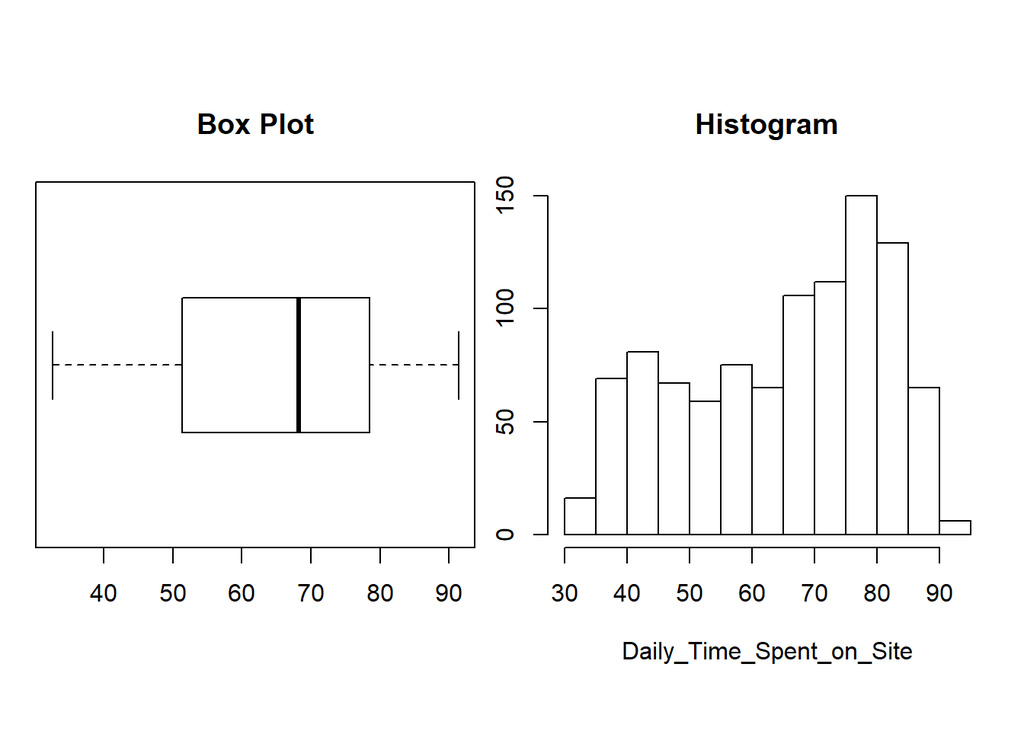

```r
Daily_Time_Spent_on_Site <- advertising$Daily.Time.Spent.on.Site
par(mfrow=c(1,2),pin=c(3,2.5)) # Set the plotting area into a 1 * 2 array
boxplot(advertising$Daily.Time.Spent.on.Site,horizontal=TRUE,main="Box Plot")
hist(Daily_Time_Spent_on_Site,main="Histogram")
```

# Univariate Analysis - Area Income

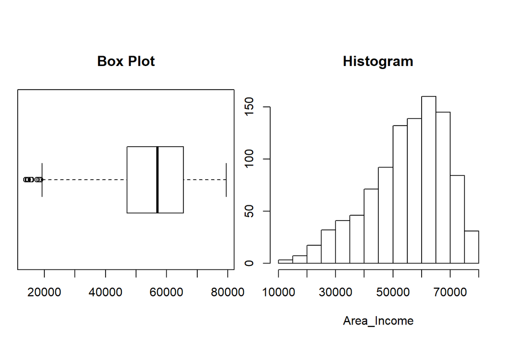

```r
par(mfrow=c(1,2),pin=c(3,2.5))
Area_Income <- advertising$Area.Income
boxplot(Area_Income, horizontal = TRUE, main="Box Plot")
hist(Area_Income, main="Histogram")
```

# Univariate Analysis - Daily Internet Usage

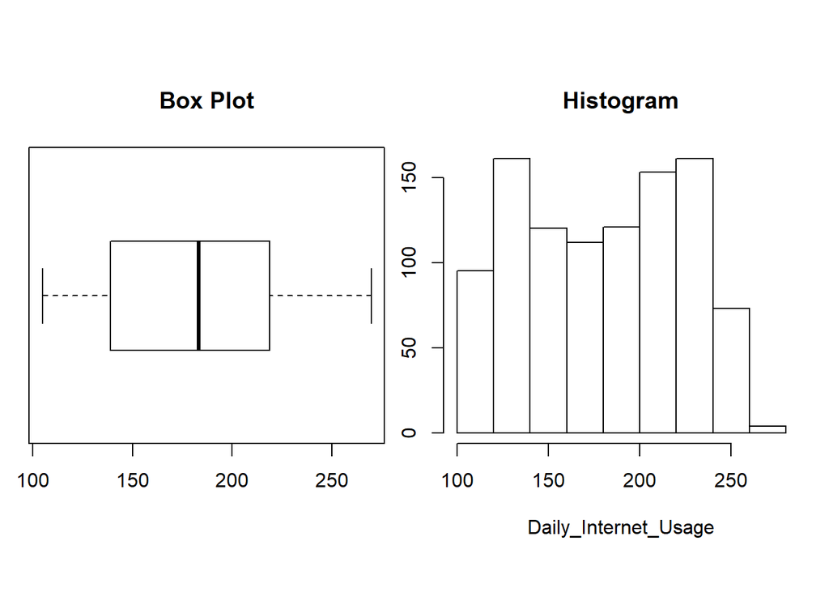

```r
Daily_Internet_Usage <- advertising$Daily.Internet.Usage
par(mfrow=c(1,2),pin=c(3,2.5)) # Set the plotting area into a 1 * 2 array
boxplot(Daily_Internet_Usage,horizontal=TRUE,main="Box Plot")
hist(Daily_Internet_Usage,main="Histogram")
```

Daily Internet Usage has no outliers and fairly distributed.

# Univariate Analysis - Gender

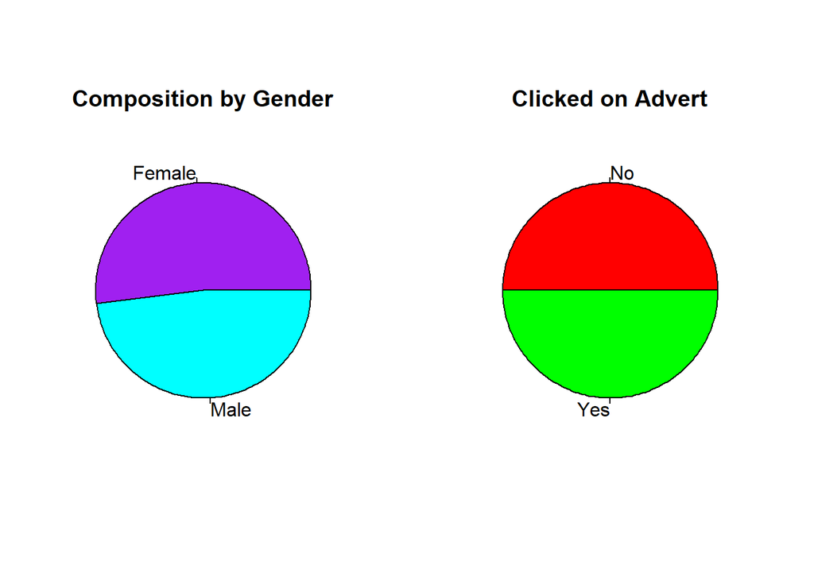

```r
Male <- advertising$Male
Clicked_On_Ad <- advertising$Clicked.on.Ad
par(mfrow=c(1,2),pin=c(3,2.5)) # Set the plotting area into a 1 * 2 array
pie(table(Male),col=c("purple","cyan"),labels=c("Female", "Male"), main="Composition by Gender")
pie(table(Clicked_On_Ad),col=c("red","green"),labels=c("No", "Yes"), main="Clicked on Advert")
```

The dataset had slightly more females than males.  
There was an equal number of clicks and no-clicks (50% -50%).

```r
Male <- advertising$Male
table(Male)
```

```
## Male
##   0   1
## 519 481
```

```r
Clicked_On_Ad <- advertising$Clicked.on.Ad
table(Clicked_On_Ad)
```

```
## Clicked_On_Ad
##   0   1
## 500 500
```

```r
clicked.freq.matrix <- table(advertising$Male,advertising$Clicked.on.Ad)
clicked.freq.matrix
```

```
##
##       0   1
##   0 250 269
##   1 250 231
```

# Univariate Analysis - Frequency distribution of Clicks

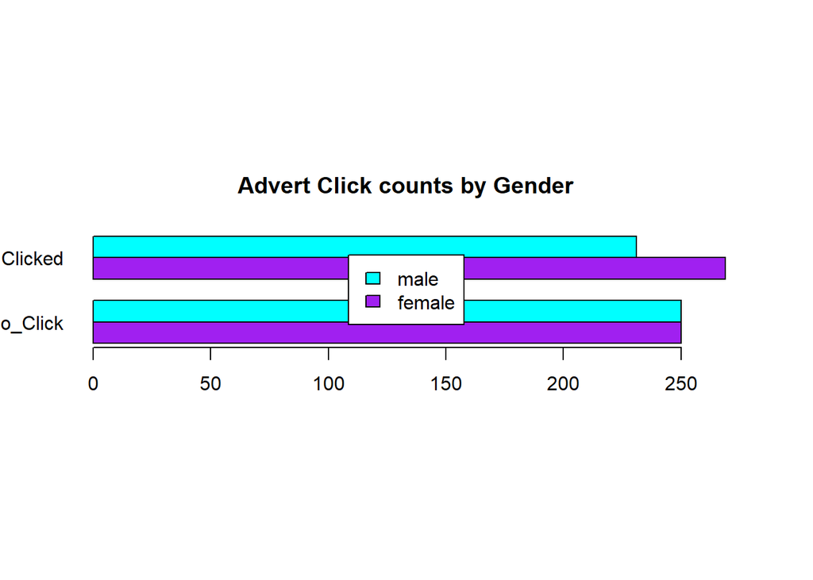

```r
par(pin=c(5.5,1))
barplot(clicked.freq.matrix,beside=TRUE,las=1, horiz=TRUE, main="Advert Click counts by Gender", col=c("purple", "cyan"), names.arg=c("No_Click","Clicked"),legend.text=c("female","male"), args.legend=list(x="center"))
```

There were more advert clicks from females than from male.

# Multivariate analysis - all numerical variables

## Correlation matrix

```r
res <- cor(advertising[,c(1,2,3,4,7,10)])
res
```

```
##                          Daily.Time.Spent.on.Site         Age  Area.Income
## Daily.Time.Spent.on.Site               1.00000000 -0.33151334  0.310954413
## Age                                   -0.33151334  1.00000000 -0.182604955
## Area.Income                            0.31095441 -0.18260496  1.000000000
## Daily.Internet.Usage                   0.51865848 -0.36720856  0.337495533
## Male                                  -0.01895085 -0.02104406  0.001322359
## Clicked.on.Ad                         -0.74811656  0.49253127 -0.476254628
##                          Daily.Internet.Usage         Male Clicked.on.Ad
## Daily.Time.Spent.on.Site           0.51865848 -0.018950855   -0.74811656
## Age                               -0.36720856 -0.021044064    0.49253127
## Area.Income                        0.33749553  0.001322359   -0.47625463
## Daily.Internet.Usage               1.00000000  0.028012326   -0.78653918
## Male                               0.02801233  1.000000000   -0.03802747
## Clicked.on.Ad                     -0.78653918 -0.038027466    1.00000000
```

## Load correlation plot library

```r
library(corrplot)
```